# CS 221 Project Progress R Code

This R-markdown file contains the R-code for the project report of my CS 221 project.

```r
library(caTools)
library(caret)
library(e1071)
library(MASS)
library(dplyr)
```

```r
library(ggplot2)
library(naniar)
#library(randomForest)
```

This “convert” helper function is due to Brigitte Mueller, [Predicting Heart Disease UCI](https://github.com/mbbrigitte/Predicting_heart_disease_UCI/blob/master/heartdisease_UCI.Rmd). I’m borrowing this helper here to change the data type of the Cleveland data read from the website.

```r
convert = function(obj,types){
    for (i in 1:length(obj)){
        FUN = switch(types[i],character = as.character,
                                   numeric = as.numeric,
                                   factor = as.factor)
        obj[,i] = FUN(obj[,i])
    }
    obj
}
```

The heart disease data are directly read from the UCI website.

```r
cleveland.data = read.csv("https://archive.ics.uci.edu/ml/machine-learning-databases/heart-disease/processed.cleveland.data",header=FALSE,sep=",",na.strings = '?')
va.data = read.csv("http://archive.ics.uci.edu/ml/machine-learning-databases/heart-disease/processed.va.data",header=FALSE,sep=",",na.strings = '?')
switzerland.data = read.csv("http://archive.ics.uci.edu/ml/machine-learning-databases/heart-disease/processed.switzerland.data",header=FALSE,sep=",",na.strings = '?')
hungarian.data = read.csv("http://archive.ics.uci.edu/ml/machine-learning-databases/heart-disease/processed.hungarian.data",header=FALSE,sep=",",na.strings = '?')
df_list <- list(cleveland.data, va.data, switzerland.data, hungarian.data)
combined.data = Reduce(function(x, y) merge(x, y, all=TRUE), df_list, accumulate=FALSE)
names(combined.data) = c( "age", "sex", "cp", "trestbps", "chol","fbs", "restecg",
                   "thalach","exang", "oldpeak","slope", "ca", "thal", "status")
combined.data$status[combined.data$status > 0] = 1
chclass = c("numeric","factor","factor","numeric","numeric","factor","factor","numeric","factor","numeric","factor","factor","factor","factor")
combined.data = convert(combined.data,chclass)
levels(combined.data$status) = c("healthy", "disease")
levels(combined.data$sex) = c("female", "male")
summary(combined.data)
```

```
##       age            sex      cp         trestbps          chol
##  Min.   :28.00   female:194   1: 46   Min.   :  0.0   Min.   :  0.0
##  1st Qu.:47.00   male  :726   2:174   1st Qu.:120.0   1st Qu.:175.0
##  Median :54.00                3:204   Median :130.0   Median :223.0
##  Mean   :53.51                4:496   Mean   :132.1   Mean   :199.1
##  3rd Qu.:60.00                        3rd Qu.:140.0   3rd Qu.:268.0
##  Max.   :77.00                        Max.   :200.0   Max.   :603.0
##                                       NA's   :59      NA's   :30
##    fbs      restecg       thalach       exang        oldpeak
##  0   :692   0   :551   Min.   : 60.0   0   :528   Min.   :-2.6000
##  1   :138   1   :179   1st Qu.:120.0   1   :337   1st Qu.: 0.0000
##  NA's: 90   2   :188   Median :140.0   NA's: 55   Median : 0.5000
##             NA's:  2   Mean   :137.5              Mean   : 0.8788
##                        3rd Qu.:157.0              3rd Qu.: 1.5000
##                        Max.   :202.0              Max.   : 6.2000
##                        NA's   :55                 NA's   :62
##   slope        ca        thal         status
##  1   :203   0   :181   3   :196   healthy:411
##  2   :345   1   : 67   6   : 46   disease:509
##  3   : 63   2   : 41   7   :192
##  NA's:309   3   : 20   NA's:486
##             NA's:611
##
##
```

```r
str(combined.data)
```

```
## 'data.frame':    920 obs. of  14 variables:
##  $ age     : num  28 29 29 29 30 31 31 32 32 32 ...
##  $ sex     : Factor w/ 2 levels "female","male": 2 2 2 2 1 1 2 1 2 2 ...
##  $ cp      : Factor w/ 4 levels "1","2","3","4": 2 2 2 2 1 2 4 2 1 2 ...
##  $ trestbps: num  130 120 130 140 170 100 120 105 95 110 ...
##  $ chol    : num  132 243 204 NA 237 219 270 198 0 225 ...
##  $ fbs     : Factor w/ 2 levels "0","1": 1 1 1 1 1 1 1 1 NA 1 ...
##  $ restecg : Factor w/ 3 levels "0","1","2": 3 1 3 1 2 2 1 1 1 1 ...
##  $ thalach : num  185 160 202 170 170 150 153 165 127 184 ...
##  $ exang   : Factor w/ 2 levels "0","1": 1 1 1 1 1 1 2 1 1 1 ...
##  $ oldpeak : num  0 0 0 0 0 0 1.5 0 0.7 0 ...
##  $ slope   : Factor w/ 3 levels "1","2","3": NA NA 1 NA NA NA 2 NA 1 NA ...
##  $ ca      : Factor w/ 4 levels "0","1","2","3": NA NA 1 NA NA NA NA NA NA NA ...
##  $ thal    : Factor w/ 3 levels "3","6","7": NA NA 1 NA 2 NA NA NA NA NA ...
##  $ status  : Factor w/ 2 levels "healthy","disease": 1 1 1 1 1 1 2 1 2 1 ...
```

Graphing missing data

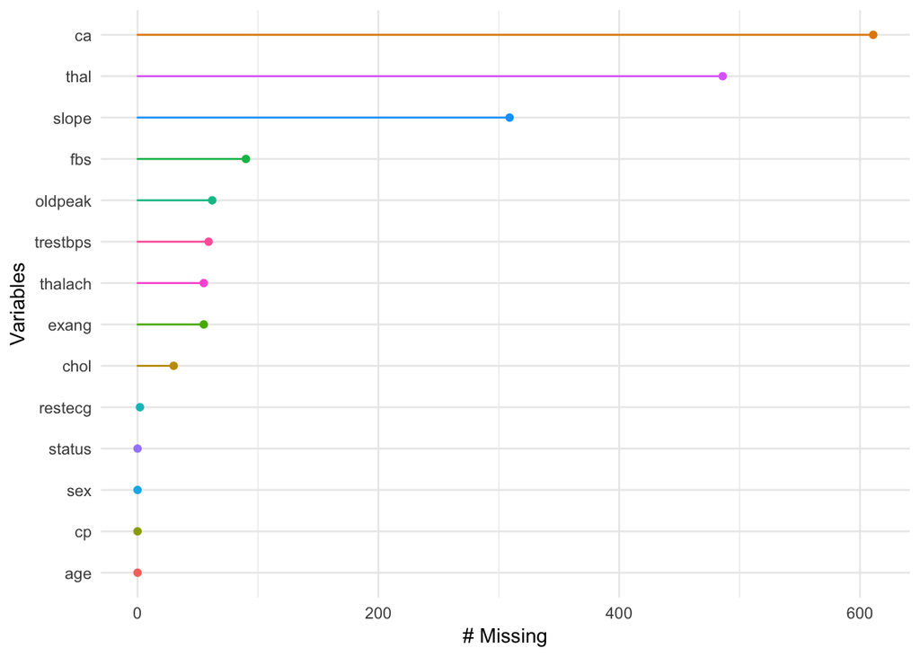

```r
gg_miss_var(combined.data)
```

Processing missing data

```r
combined.data = subset(combined.data, select = -c(11, 12, 13))
combined.data = na.omit(combined.data)
```

Graphics for data exploration

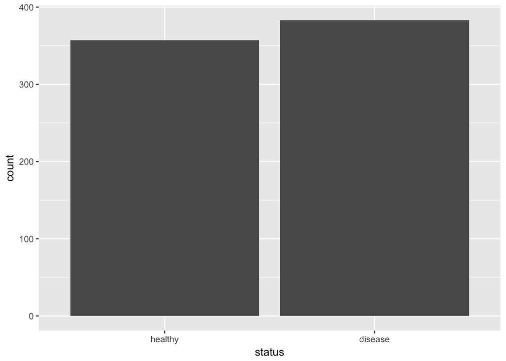

```r
ggplot(combined.data, aes(x = status)) + geom_bar()
```

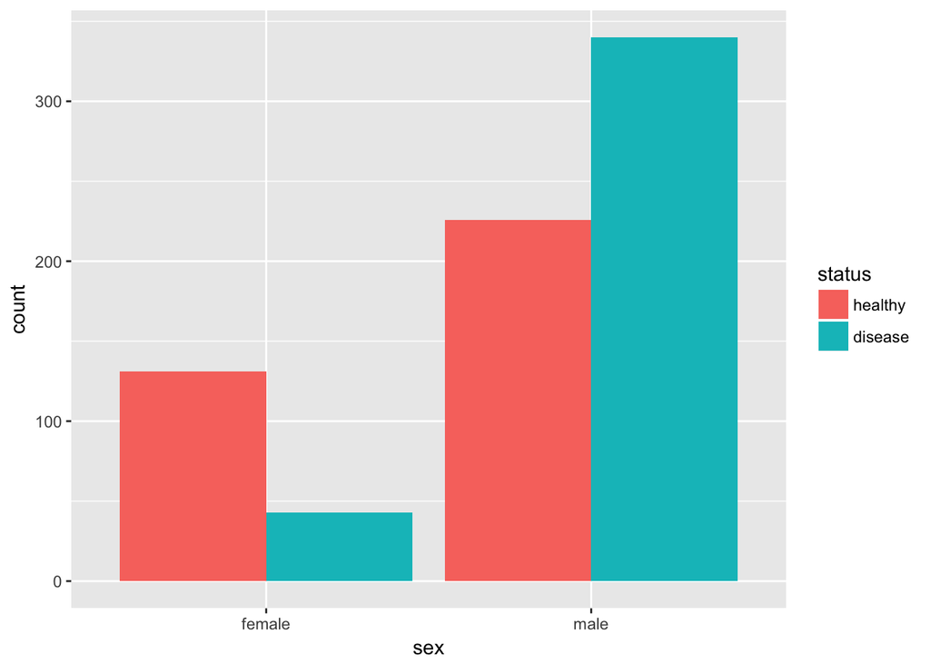

```r
ggplot(combined.data, aes(x = sex, fill=status)) + geom_bar(position="dodge")
```

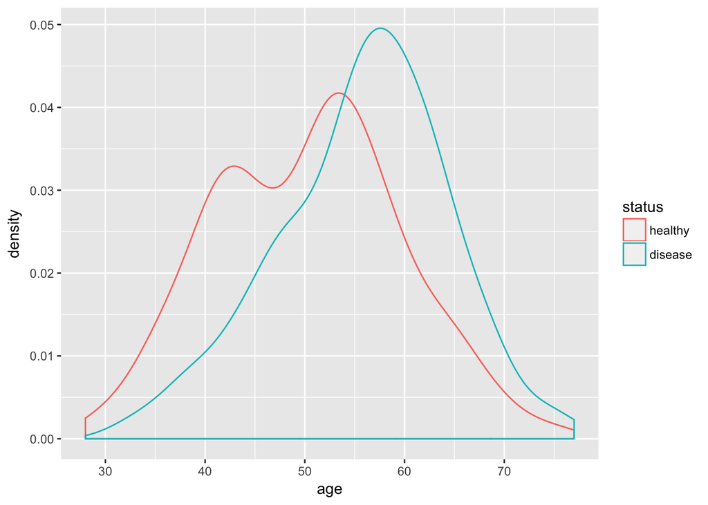

```r
ggplot(combined.data, aes(x=age, color = status)) + geom_density()
```

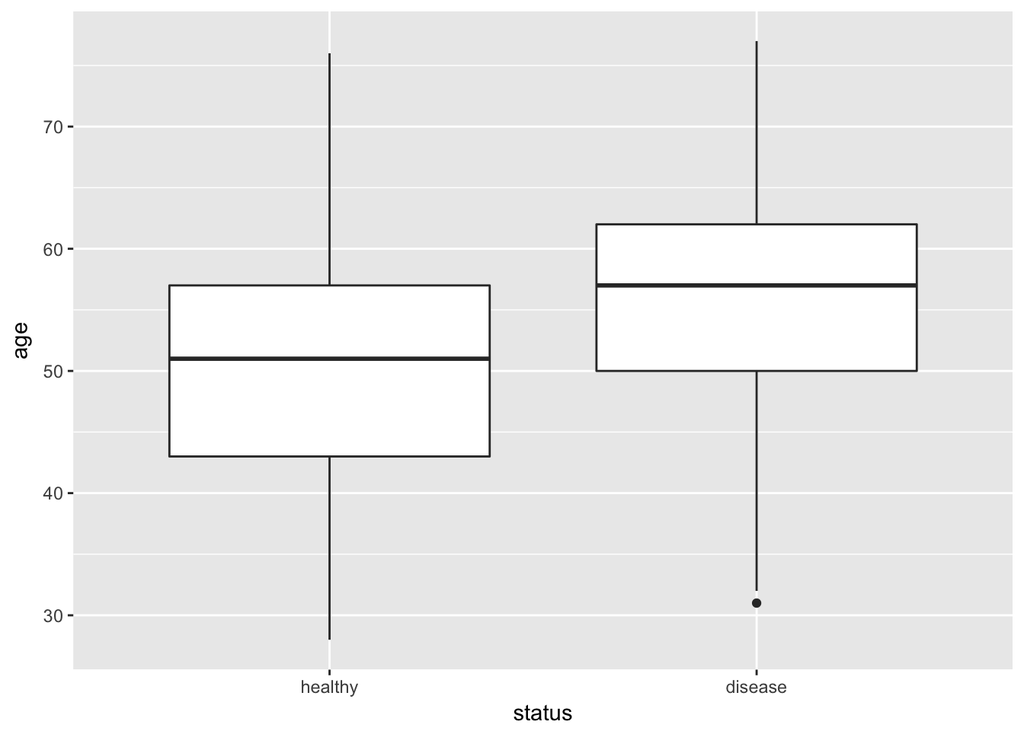

```r
ggplot(combined.data, aes(x=status, y = age)) + geom_boxplot()
```

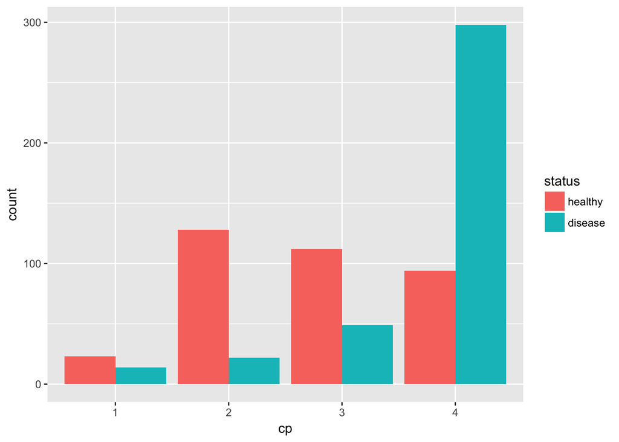

```r
ggplot(combined.data, aes(x = cp, fill=status)) + geom_bar(position="dodge")
```

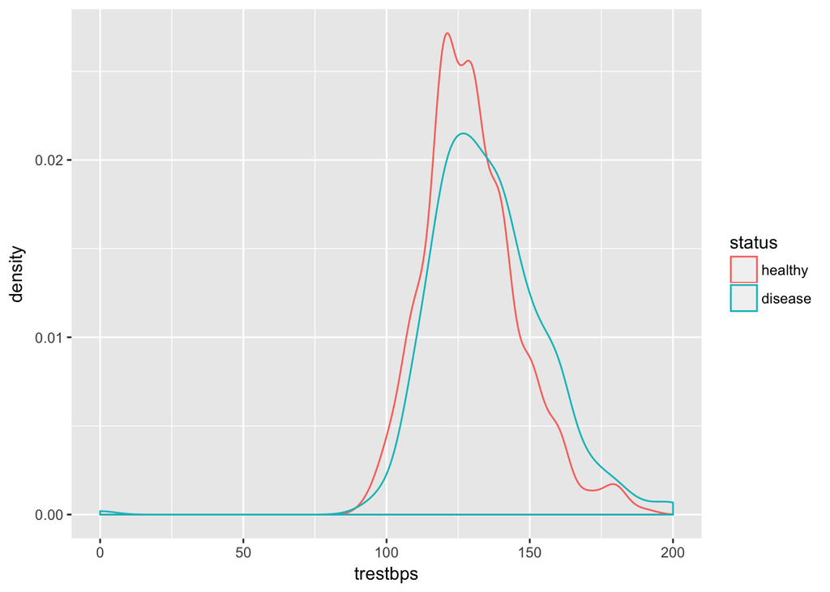

```r
ggplot(combined.data, aes(x=trestbps, color = status)) + geom_density()
```

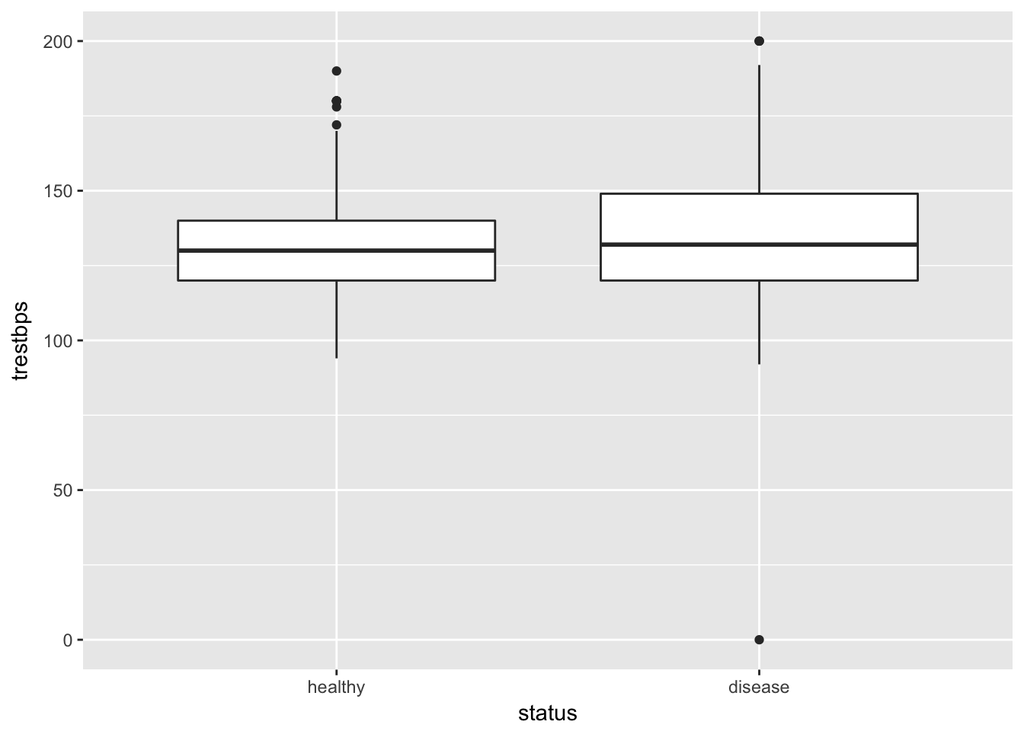

```r
ggplot(combined.data, aes(x=status, y = trestbps)) + geom_boxplot()
```

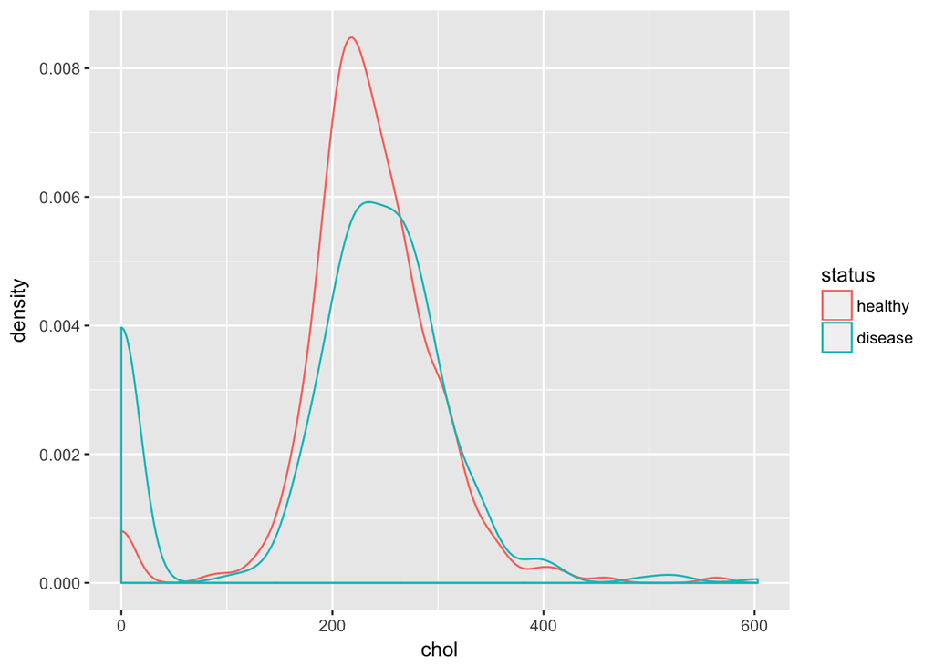

```r
ggplot(combined.data, aes(x=chol, color = status)) + geom_density()
```

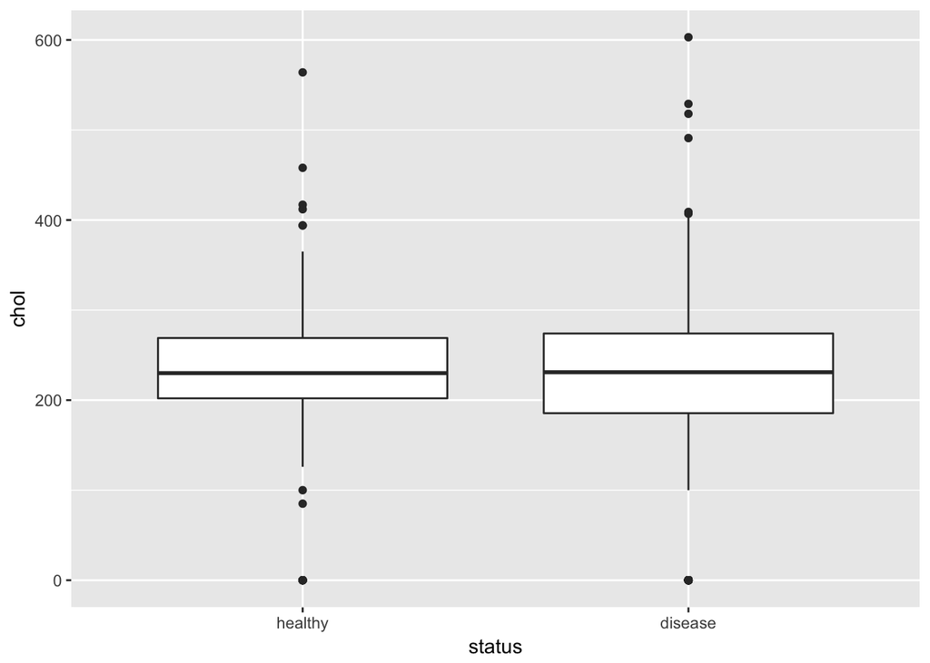

```r
ggplot(combined.data, aes(x=status, y = chol)) + geom_boxplot()
```

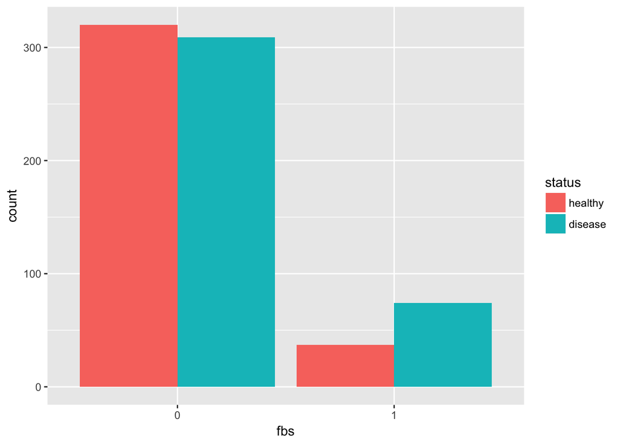

```r
ggplot(combined.data, aes(x = fbs, fill=status)) + geom_bar(position="dodge")
```

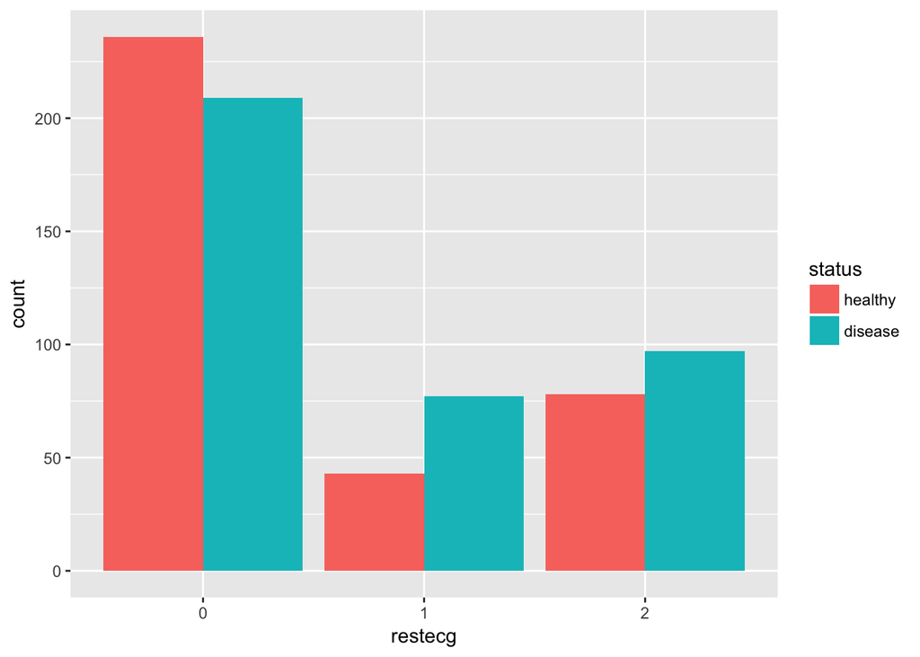

```r
ggplot(combined.data, aes(x = restecg, fill=status)) + geom_bar(position="dodge")
```

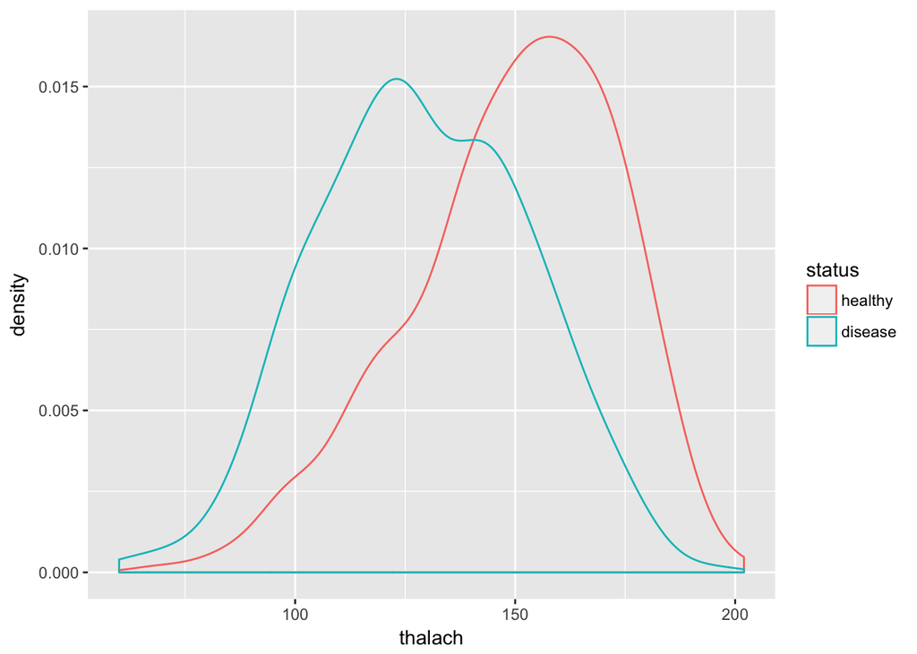

```r
ggplot(combined.data, aes(x=thalach, color = status)) + geom_density()
```

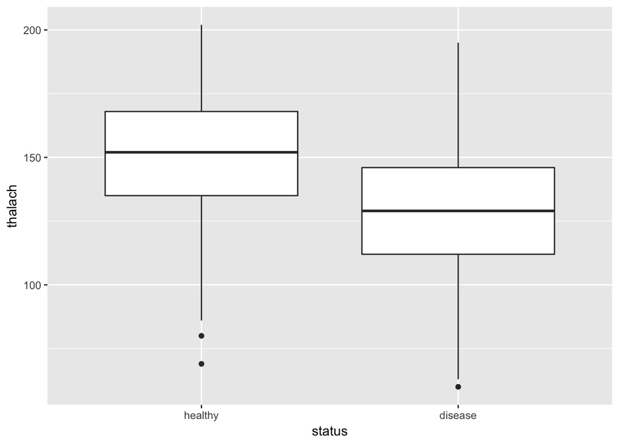

```r
ggplot(combined.data, aes(x=status, y = thalach)) + geom_boxplot()
```

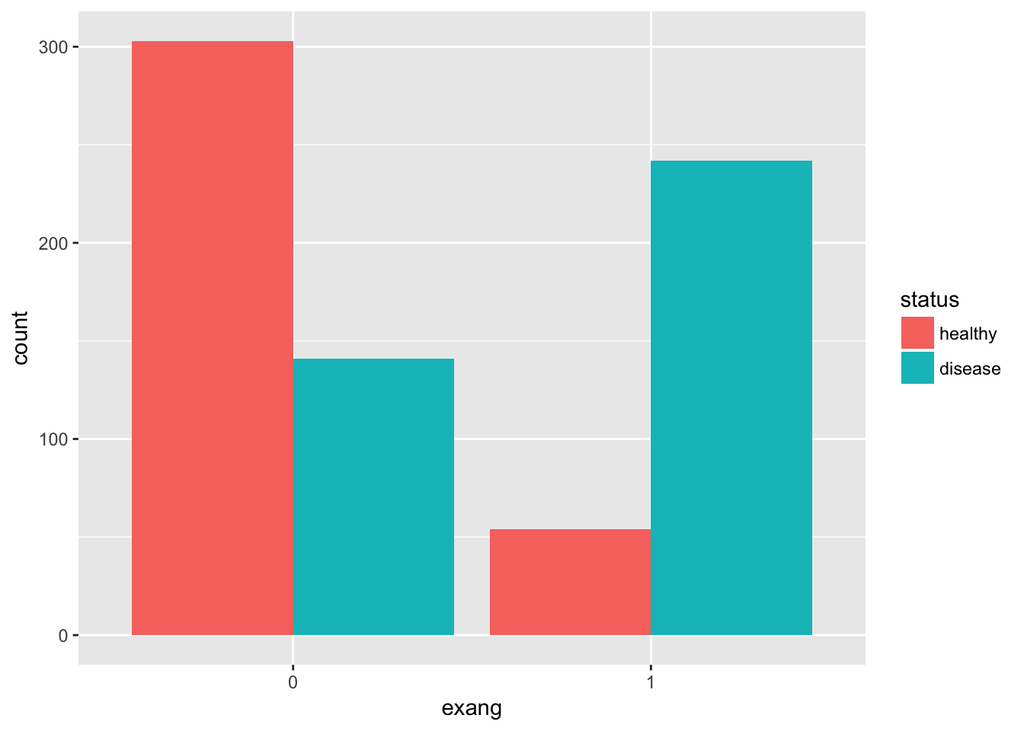

```r
ggplot(combined.data, aes(x = exang, fill=status)) + geom_bar(position="dodge")
```

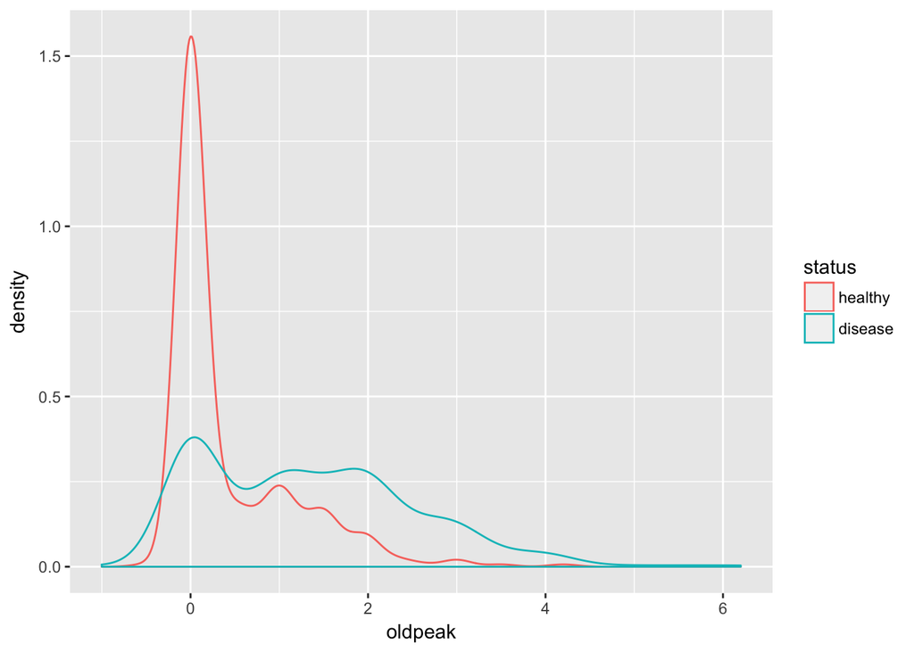

```r
ggplot(combined.data, aes(x=oldpeak, color = status)) + geom_density()
```

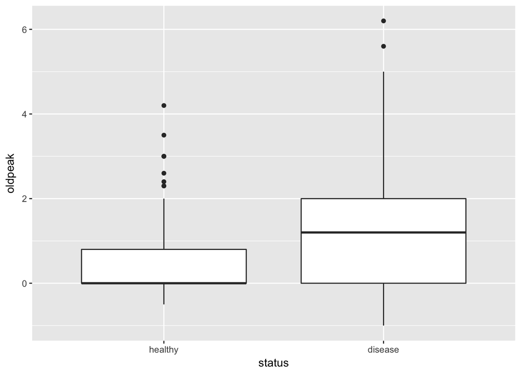

```r
ggplot(combined.data, aes(x=status, y = oldpeak)) + geom_boxplot()
```

Splitting training and testing data

```r
set.seed(100)
sample = sample.split(combined.data, SplitRatio = 0.70)
train = subset(combined.data, sample == T)
test = subset(combined.data, sample == F)
summary(test)
```

```
##       age           sex      cp         trestbps          chol
##  Min.   :29.0   female: 67   1: 14   Min.   :  0.0   Min.   :  0.0
##  1st Qu.:46.0   male  :202   2: 53   1st Qu.:120.0   1st Qu.:203.0
##  Median :54.0                3: 59   Median :130.0   Median :234.0
##  Mean   :53.2                4:143   Mean   :132.3   Mean   :220.9
##  3rd Qu.:60.0                        3rd Qu.:140.0   3rd Qu.:268.0
##  Max.   :77.0                        Max.   :200.0   Max.   :564.0
##  fbs     restecg    thalach      exang      oldpeak           status
##  0:228   0:166   Min.   : 69.0   0:164   Min.   :0.0000   healthy:128
##  1: 41   1: 44   1st Qu.:120.0   1:105   1st Qu.:0.0000   disease:141
##          2: 59   Median :140.0           Median :0.4000
##                  Mean   :139.4           Mean   :0.8643
##                  3rd Qu.:160.0           3rd Qu.:1.5000
##                  Max.   :202.0           Max.   :5.0000
```

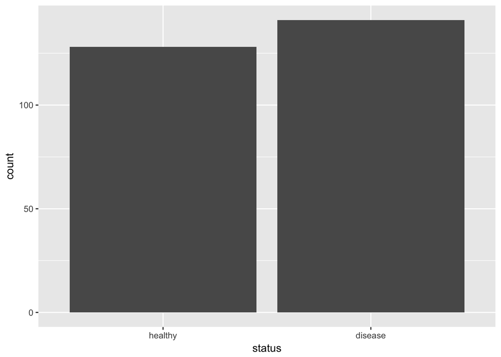

```r
ggplot(test, aes(x = status)) + geom_bar()
```

Baseline approach: Logistic regression (both with full model training, and with the selected five predictors)

```r
logit.model = train(status ~ ., data=train, method = 'glm', family = 'binomial')
summary(logit.model)
```

```
##
## Call:
## NULL
##
## Deviance Residuals:
##     Min       1Q   Median       3Q      Max
## -2.8479  -0.6053   0.1551   0.5699   2.6069
##
## Coefficients:
##               Estimate Std. Error z value Pr(>|z|)
## (Intercept) -2.9049653  1.7734166  -1.638 0.101409
## age          0.0162828  0.0161423   1.009 0.313119
## sexmale      1.3139698  0.3380953   3.886 0.000102 ***
## cp2         -0.0368386  0.6284873  -0.059 0.953259
## cp3          0.2472175  0.5918941   0.418 0.676187
## cp4          1.5137979  0.5736822   2.639 0.008321 **
## trestbps     0.0138848  0.0075800   1.832 0.066986 .
## chol        -0.0009002  0.0015325  -0.587 0.556919
## fbs1         0.5491646  0.3725546   1.474 0.140468
## restecg1     0.0207829  0.3743793   0.056 0.955730
## restecg2     0.3275127  0.3183371   1.029 0.303562
## thalach     -0.0187948  0.0058359  -3.221 0.001279 **
## exang1       0.9493386  0.2832175   3.352 0.000802 ***
## oldpeak      0.7788933  0.1484223   5.248 1.54e-07 ***
## ---
## Signif. codes:  0 '***' 0.001 '**' 0.01 '*' 0.05 '.' 0.1 ' ' 1
##
## (Dispersion parameter for binomial family taken to be 1)
##
##     Null deviance: 652.59  on 470  degrees of freedom
## Residual deviance: 390.26  on 457  degrees of freedom
## AIC: 418.26
##
## Number of Fisher Scoring iterations: 5
```

```r
logit.result = predict(logit.model, test)
confusionMatrix(test$status, logit.result)
```

```
## Confusion Matrix and Statistics
##
##           Reference
## Prediction healthy disease
##    healthy     109      19
##    disease      35     106
##
##                Accuracy : 0.7993
##                  95% CI : (0.7463, 0.8454)
##     No Information Rate : 0.5353
##     P-Value [Acc > NIR] : < 2e-16
##
##                   Kappa : 0.5999
##  Mcnemar's Test P-Value : 0.04123
##
##             Sensitivity : 0.7569
##             Specificity : 0.8480
##          Pos Pred Value : 0.8516
##          Neg Pred Value : 0.7518
##              Prevalence : 0.5353
##          Detection Rate : 0.4052
##    Detection Prevalence : 0.4758
##       Balanced Accuracy : 0.8025
##
##        'Positive' Class : healthy
##
```

```r
smalllogit.model = train(status ~ sex +cp + thalach +exang +oldpeak, data=train, method = 'glm', family = 'binomial')
smalllogit.result = predict(smalllogit.model, test)
confusionMatrix(test$status, smalllogit.result)
```

```
## Confusion Matrix and Statistics
##
##           Reference
## Prediction healthy disease
##    healthy     108      20
##    disease      32     109
##
##                Accuracy : 0.8067
##                  95% CI : (0.7544, 0.8521)
##     No Information Rate : 0.5204
##     P-Value [Acc > NIR] : <2e-16
##
##                   Kappa : 0.6141
##  Mcnemar's Test P-Value : 0.1272
##
##             Sensitivity : 0.7714
##             Specificity : 0.8450
##          Pos Pred Value : 0.8438
##          Neg Pred Value : 0.7730
##              Prevalence : 0.5204
##          Detection Rate : 0.4015
##    Detection Prevalence : 0.4758
##       Balanced Accuracy : 0.8082
##
##        'Positive' Class : healthy
##
```

variable importance for logistic model

```r
importance = varImp(logit.model, scale=FALSE)
importance
```

```
## glm variable importance
##
##          Overall
## oldpeak  5.24782
## sexmale  3.88639
## exang1   3.35198
## thalach  3.22054
## cp4      2.63874
## trestbps 1.83177
## fbs1     1.47405
## restecg2 1.02882
## age      1.00870
## chol     0.58742
## cp3      0.41767
## cp2      0.05861
## restecg1 0.05551
```

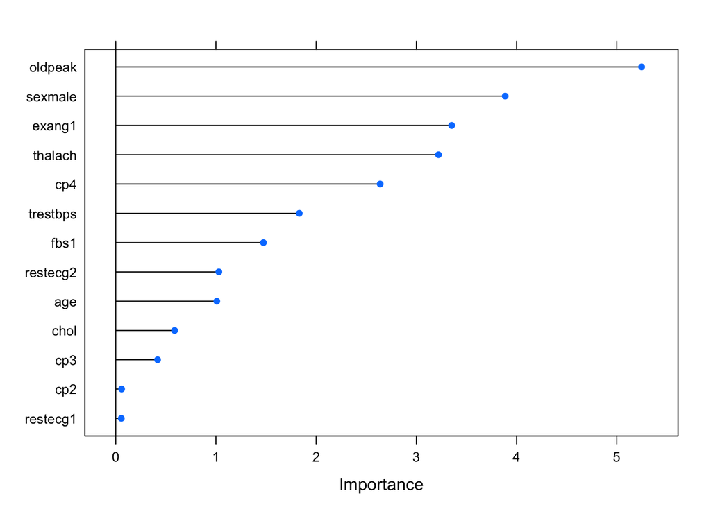

```r
plot(importance)
```

Approach 2: Naive Bayes classification, with both full model, a small model with 5 predictors, and a “best” model that includes all the predictors except trestbps.

```r
naiveBayes.model = naiveBayes(status ~., data = train)
naiveBayes.model
```

```
##
## Naive Bayes Classifier for Discrete Predictors
##
## Call:
## naiveBayes.default(x = X, y = Y, laplace = laplace)
##
## A-priori probabilities:
## Y
##   healthy   disease
## 0.4861996 0.5138004
##
## Conditional probabilities:
##          age
## Y             [,1]     [,2]
##   healthy 50.30131 9.527479
##   disease 55.63223 8.548681
##
##          sex
## Y            female      male
##   healthy 0.3580786 0.6419214
##   disease 0.1033058 0.8966942
##
##          cp
## Y                  1          2          3          4
##   healthy 0.06550218 0.34934498 0.31441048 0.27074236
##   disease 0.03305785 0.07024793 0.12396694 0.77272727
##
##          trestbps
## Y             [,1]     [,2]
##   healthy 129.7380 16.77721
##   disease 136.0744 18.21457
##
##          chol
## Y             [,1]     [,2]
##   healthy 230.5939  65.9265
##   disease 209.3430 109.4753
##
##          fbs
## Y                 0         1
##   healthy 0.8908297 0.1091703
##   disease 0.8140496 0.1859504
##
##          restecg
## Y                 0         1         2
##   healthy 0.6593886 0.1179039 0.2227074
##   disease 0.5289256 0.2024793 0.2685950
##
##          thalach
## Y             [,1]     [,2]
##   healthy 149.2314 22.97049
##   disease 128.0372 23.89766
##
##          exang
## Y                 0         1
##   healthy 0.8384279 0.1615721
##   disease 0.3636364 0.6363636
##
##          oldpeak
## Y              [,1]      [,2]
##   healthy 0.4039301 0.6572352
##   disease 1.3917355 1.2229538
```

```r
naiveBayes.result = predict(naiveBayes.model, train)
confusionMatrix(train$status, naiveBayes.result)
```

```
## Confusion Matrix and Statistics
##
##           Reference
## Prediction healthy disease
##    healthy     188      41
##    disease      47     195
##
##                Accuracy : 0.8132
##                  95% CI : (0.775, 0.8474)
##     No Information Rate : 0.5011
##     P-Value [Acc > NIR] : <2e-16
##
##                   Kappa : 0.6263
##  Mcnemar's Test P-Value : 0.594
##
##             Sensitivity : 0.8000
##             Specificity : 0.8263
##          Pos Pred Value : 0.8210
##          Neg Pred Value : 0.8058
##              Prevalence : 0.4989
##          Detection Rate : 0.3992
##    Detection Prevalence : 0.4862
##       Balanced Accuracy : 0.8131
##
##        'Positive' Class : healthy
##
```

```r
smallnaiveBayes.model = naiveBayes(status ~sex +cp + thalach +exang +oldpeak, data = train)
smallnaiveBayes.result = predict(smallnaiveBayes.model, test)
confusionMatrix(test$status, smallnaiveBayes.result)
```

```
## Confusion Matrix and Statistics
##
##           Reference
## Prediction healthy disease
##    healthy     108      20
##    disease      35     106
##
##                Accuracy : 0.7955
##                  95% CI : (0.7423, 0.8421)
##     No Information Rate : 0.5316
##     P-Value [Acc > NIR] : < 2e-16
##
##                   Kappa : 0.5923
##  Mcnemar's Test P-Value : 0.05906
##
##             Sensitivity : 0.7552
##             Specificity : 0.8413
##          Pos Pred Value : 0.8438
##          Neg Pred Value : 0.7518
##              Prevalence : 0.5316
##          Detection Rate : 0.4015
##    Detection Prevalence : 0.4758
##       Balanced Accuracy : 0.7983
##
##        'Positive' Class : healthy
##
```

```r
bestnaiveBayes.model = naiveBayes(status ~sex +cp + thalach +exang +oldpeak+restecg+fbs+chol+age, data = train)
bestnaiveBayes.result = predict(bestnaiveBayes.model, test)
confusionMatrix(test$status, bestnaiveBayes.result)
```

```
## Confusion Matrix and Statistics
##
##           Reference
## Prediction healthy disease
##    healthy     109      19
##    disease      24     117
##
##                Accuracy : 0.8401
##                  95% CI : (0.7908, 0.8818)
##     No Information Rate : 0.5056
##     P-Value [Acc > NIR] : <2e-16
##
##                   Kappa : 0.6801
##  Mcnemar's Test P-Value : 0.5419
##
##             Sensitivity : 0.8195
##             Specificity : 0.8603
##          Pos Pred Value : 0.8516
##          Neg Pred Value : 0.8298
##              Prevalence : 0.4944
##          Detection Rate : 0.4052
##    Detection Prevalence : 0.4758
##       Balanced Accuracy : 0.8399
##
##        'Positive' Class : healthy
##
```

Approach 3: Support vector machines, using a 3-repeat, 10-fold cross validation to fine tune the hyperparameters C, using Gaussian radial kernel. Includes both the results of the full model and a small model with the selected 5 predictors.

```r
fitControl = trainControl(method = "repeatedcv", number = 10, repeats = 3)
set.seed(100)
svm.model = train(status ~., data = train, method = "svmRadial", trControl = fitControl)
svm.model
```

```
## Support Vector Machines with Radial Basis Function Kernel
##
## 471 samples
##  10 predictor
##   2 classes: 'healthy', 'disease'
##
## No pre-processing
## Resampling: Cross-Validated (10 fold, repeated 3 times)
## Summary of sample sizes: 424, 424, 424, 424, 424, 424, ...
## Resampling results across tuning parameters:
##
##   C     Accuracy   Kappa
##   0.25  0.7890052  0.5774449
##   0.50  0.7911630  0.5825566
##   1.00  0.7926425  0.5856137
##
## Tuning parameter 'sigma' was held constant at a value of 0.05299966
## Accuracy was used to select the optimal model using the largest value.
## The final values used for the model were sigma = 0.05299966 and C = 1.
```

```r
svm.result = predict(svm.model, newdata = test)
confusionMatrix(test$status, svm.result)
```

```
## Confusion Matrix and Statistics
##
##           Reference
## Prediction healthy disease
##    healthy     111      17
##    disease      33     108
##
##                Accuracy : 0.8141
##                  95% CI : (0.7624, 0.8588)
##     No Information Rate : 0.5353
##     P-Value [Acc > NIR] : < 2e-16
##
##                   Kappa : 0.6295
##  Mcnemar's Test P-Value : 0.03389
##
##             Sensitivity : 0.7708
##             Specificity : 0.8640
##          Pos Pred Value : 0.8672
##          Neg Pred Value : 0.7660
##              Prevalence : 0.5353
##          Detection Rate : 0.4126
##    Detection Prevalence : 0.4758
##       Balanced Accuracy : 0.8174
##
##        'Positive' Class : healthy
##
```

```r
set.seed(100)
smallsvm.model = train(status ~sex +cp + thalach +exang +oldpeak, data = train,
                 method = "svmRadial",
                 trControl = fitControl)
smallsvm.result = predict(smallsvm.model, newdata = test)
confusionMatrix(test$status, smallsvm.result)
```

```
## Confusion Matrix and Statistics
##
##           Reference
## Prediction healthy disease
##    healthy     112      16
##    disease      41     100
##
##                Accuracy : 0.7881
##                  95% CI : (0.7344, 0.8354)
##     No Information Rate : 0.5688
##     P-Value [Acc > NIR] : 3.319e-14
##
##                   Kappa : 0.579
##  Mcnemar's Test P-Value : 0.001478
##
##             Sensitivity : 0.7320
##             Specificity : 0.8621
##          Pos Pred Value : 0.8750
##          Neg Pred Value : 0.7092
##              Prevalence : 0.5688
##          Detection Rate : 0.4164
##    Detection Prevalence : 0.4758
##       Balanced Accuracy : 0.7970
##
##        'Positive' Class : healthy
##
```

Variable importance for the full svm model.

```r
importance = varImp(svm.model, scale=FALSE)
importance
```

```
## ROC curve variable importance
##
##          Importance
## cp           0.7570
## oldpeak      0.7479
## thalach      0.7430
## exang        0.7374
## age          0.6689
## sex          0.6274
## trestbps     0.6037
## restecg      0.5585
## fbs          0.5384
## chol         0.5180
```

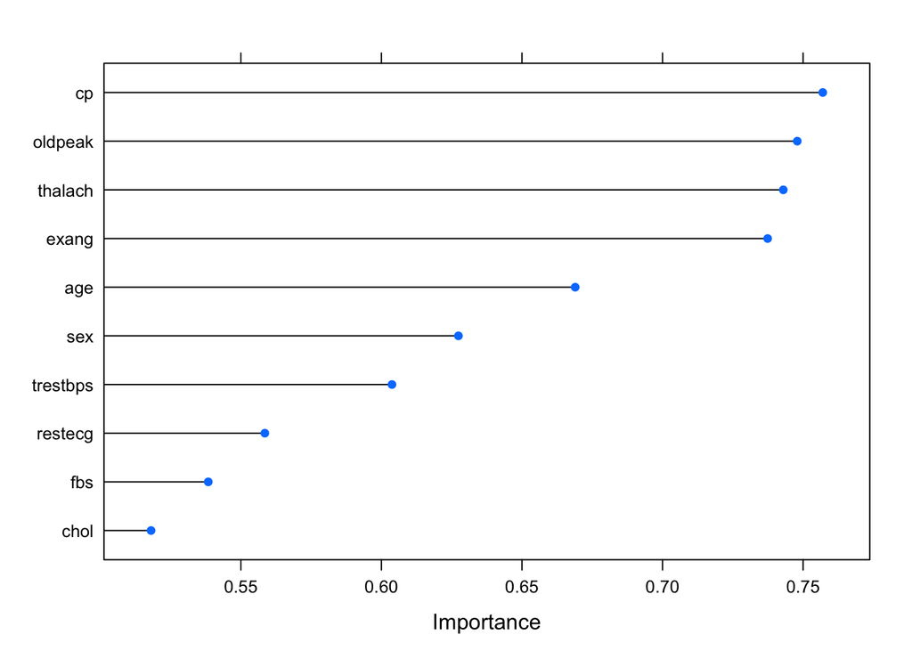

```r
plot(importance)
```

Approach 4: Random forests, with 10 fold, 3 repeat cross validation to tune the parameter mtry. With results from both the full model and the small model using the 5 selected predictors

```r
fitControl = trainControl(method = "repeatedcv", number = 10, repeats = 3)
set.seed(100)
rf.model = train(status~., data=train, method="rf", trControl = fitControl)
rf.model
```

```
## Random Forest
##
## 471 samples
##  10 predictor
##   2 classes: 'healthy', 'disease'
##
## No pre-processing
## Resampling: Cross-Validated (10 fold, repeated 3 times)
## Summary of sample sizes: 424, 424, 424, 424, 424, 424, ...
## Resampling results across tuning parameters:
##
##   mtry  Accuracy   Kappa
##    2    0.7855053  0.5706418
##    7    0.7685130  0.5366725
##   13    0.7550667  0.5098978
##
## Accuracy was used to select the optimal model using the largest value.
## The final value used for the model was mtry = 2.
```

```r
rf.result = predict(rf.model, test)
confusionMatrix(test$status, rf.result)
```

```
## Confusion Matrix and Statistics
##
##           Reference
## Prediction healthy disease
##    healthy     109      19
##    disease      30     111
##
##                Accuracy : 0.8178
##                  95% CI : (0.7664, 0.8621)
##     No Information Rate : 0.5167
##     P-Value [Acc > NIR] : <2e-16
##
##                   Kappa : 0.6363
##  Mcnemar's Test P-Value : 0.1531
##
##             Sensitivity : 0.7842
##             Specificity : 0.8538
##          Pos Pred Value : 0.8516
##          Neg Pred Value : 0.7872
##              Prevalence : 0.5167
##          Detection Rate : 0.4052
##    Detection Prevalence : 0.4758
##       Balanced Accuracy : 0.8190
##
##        'Positive' Class : healthy
##
```

```r
predictors(rf.model)
```

```
##  [1] "age"      "sexmale"  "cp2"      "cp3"      "cp4"      "trestbps"
##  [7] "chol"     "fbs1"     "restecg1" "restecg2" "thalach"  "exang1"
## [13] "oldpeak"
```

Small random forests model using only the 5 selected predictors.

```r
set.seed(100)
fitControl = trainControl(method = "repeatedcv", number = 10, repeats = 3)
smallrf.model = train(status~sex +cp + thalach +exang +oldpeak, data=train, method="rf")
smallrf.model
```

```
## Random Forest
##
## 471 samples
##   5 predictor
##   2 classes: 'healthy', 'disease'
##
## No pre-processing
## Resampling: Bootstrapped (25 reps)
## Summary of sample sizes: 471, 471, 471, 471, 471, 471, ...
## Resampling results across tuning parameters:
##
##   mtry  Accuracy   Kappa
##   2     0.7731039  0.5455893
##   4     0.7484221  0.4966682
##   7     0.7363129  0.4727022
##
## Accuracy was used to select the optimal model using the largest value.
## The final value used for the model was mtry = 2.
```

```r
smallrf.result = predict(smallrf.model, test)
confusionMatrix(test$status, smallrf.result)
```

```
## Confusion Matrix and Statistics
##
##           Reference
## Prediction healthy disease
##    healthy     107      21
##    disease      36     105
##
##                Accuracy : 0.7881
##                  95% CI : (0.7344, 0.8354)
##     No Information Rate : 0.5316
##     P-Value [Acc > NIR] : < 2e-16
##
##                   Kappa : 0.5775
##  Mcnemar's Test P-Value : 0.06369
##
##             Sensitivity : 0.7483
##             Specificity : 0.8333
##          Pos Pred Value : 0.8359
##          Neg Pred Value : 0.7447
##              Prevalence : 0.5316
##          Detection Rate : 0.3978
##    Detection Prevalence : 0.4758
##       Balanced Accuracy : 0.7908
##
##        'Positive' Class : healthy
##
```

Variable importance for the full random forest model

```r
importance = varImp(rf.model, scale=FALSE)
importance
```

```
## rf variable importance
##
##          Overall
## thalach   29.115
## oldpeak   27.043
## cp4       22.971
## age       20.156
## exang1    19.875
## chol      19.073
## trestbps  16.695
## sexmale    9.497
## cp2        9.348
## cp3        5.525
## fbs1       4.020
## restecg1   3.821
## restecg2   3.149
```

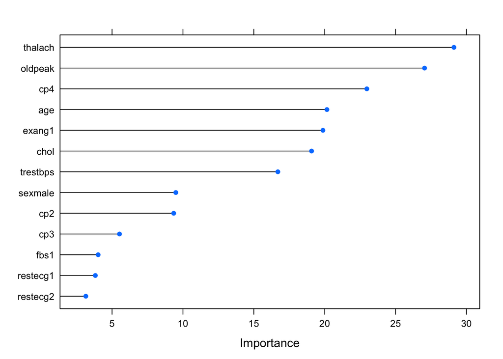

```r
plot(importance)
```

Variable selection via recursive variable elimination using random forests

```r
set.seed(100)
control = rfeControl(functions=rfFuncs, method="cv", number=10, repeats = 3, returnResamp = "all")
results = rfe(train[, 1:10], train[, 11],  rfeControl=control)
results
```

```
##
## Recursive feature selection
##
## Outer resampling method: Cross-Validated (10 fold)
##
## Resampling performance over subset size:
##
##  Variables Accuracy  Kappa AccuracySD KappaSD Selected
##          4   0.7284 0.4564    0.06860  0.1375
##          8   0.7538 0.5078    0.05571  0.1113
##         10   0.7580 0.5162    0.06024  0.1197        *
##
## The top 5 variables (out of 10):
##    cp, oldpeak, exang, sex, thalach
```

```r
print(results)
```

```
##
## Recursive feature selection
##
## Outer resampling method: Cross-Validated (10 fold)
##
## Resampling performance over subset size:
##
##  Variables Accuracy  Kappa AccuracySD KappaSD Selected
##          4   0.7284 0.4564    0.06860  0.1375
##          8   0.7538 0.5078    0.05571  0.1113
##         10   0.7580 0.5162    0.06024  0.1197        *
##
## The top 5 variables (out of 10):
##    cp, oldpeak, exang, sex, thalach
```

```r
predictors(results)
```

```
##  [1] "cp"       "oldpeak"  "exang"    "sex"      "thalach"  "age"
##  [7] "fbs"      "chol"     "restecg"  "trestbps"
```

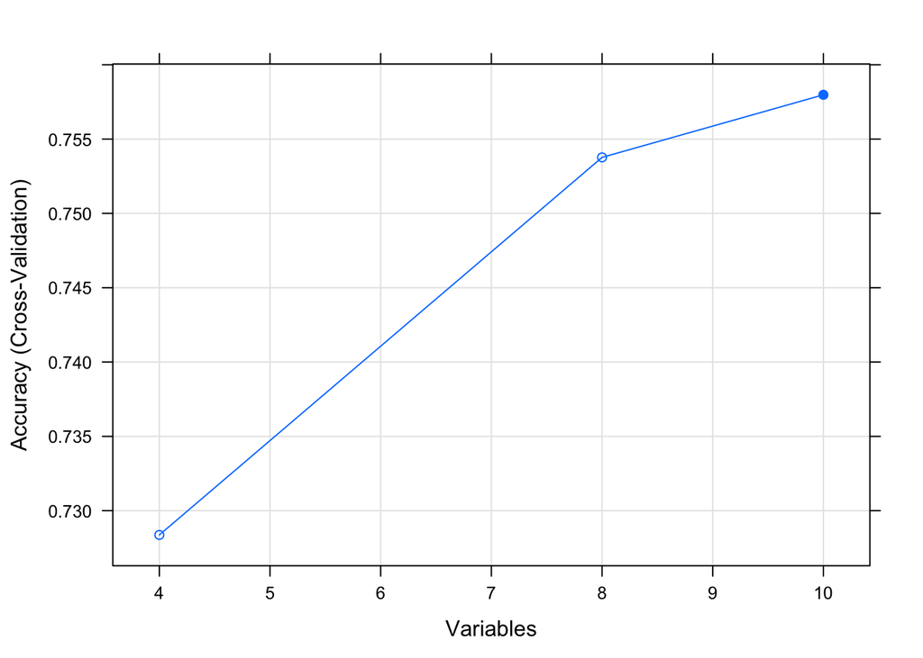

```r
plot(results, type = c("g", "o"))
```

Approach 5: Single layer neural network, using 10 fold, 3 repeat cross validation to tune the parameters size and decay.

```r
fitControl = trainControl(method = "repeatedcv", number = 10, repeats = 3)
set.seed(100)
nnet.model = train(status ~ ., data = train, method = "nnet",  trControl = fitControl, verbose = FALSE, trace=FALSE)
nnet.model
```

```
## Neural Network
##
## 471 samples
##  10 predictor
##   2 classes: 'healthy', 'disease'
##
## No pre-processing
## Resampling: Cross-Validated (10 fold, repeated 3 times)
## Summary of sample sizes: 424, 424, 424, 424, 424, 424, ...
## Resampling results across tuning parameters:
##
##   size  decay  Accuracy   Kappa
##   1     0e+00  0.5762129  0.1388614
##   1     1e-04  0.5661360  0.1161913
##   1     1e-01  0.7755011  0.5522494
##   3     0e+00  0.6563483  0.3152133
##   3     1e-04  0.6554091  0.3066531
##   3     1e-01  0.7962181  0.5927021
##   5     0e+00  0.7206413  0.4429703
##   5     1e-04  0.7256090  0.4526095
##   5     1e-01  0.7826678  0.5655450
##
## Accuracy was used to select the optimal model using the largest value.
## The final values used for the model were size = 3 and decay = 0.1.
```

```r
nnet.result = predict(nnet.model, test)
confusionMatrix(test$status, nnet.result)
```

```
## Confusion Matrix and Statistics
##
##           Reference
## Prediction healthy disease
##    healthy     113      15
##    disease      37     104
##
##                Accuracy : 0.8067
##                  95% CI : (0.7544, 0.8521)
##     No Information Rate : 0.5576
##     P-Value [Acc > NIR] : < 2.2e-16
##
##                   Kappa : 0.6155
##  Mcnemar's Test P-Value : 0.003589
##
##             Sensitivity : 0.7533
##             Specificity : 0.8739
##          Pos Pred Value : 0.8828
##          Neg Pred Value : 0.7376
##              Prevalence : 0.5576
##          Detection Rate : 0.4201
##    Detection Prevalence : 0.4758
##       Balanced Accuracy : 0.8136
##
##        'Positive' Class : healthy
##
```

```r
set.seed(100)
smallnnet.model = train(status ~ sex +cp + thalach +exang +oldpeak, data = train, method = "nnet",  trControl = fitControl, verbose = FALSE, trace=FALSE)
smallnnet.model
```

```
## Neural Network
##
## 471 samples
##   5 predictor
##   2 classes: 'healthy', 'disease'
##
## No pre-processing
## Resampling: Cross-Validated (10 fold, repeated 3 times)
## Summary of sample sizes: 424, 424, 424, 424, 424, 424, ...
## Resampling results across tuning parameters:
##
##   size  decay  Accuracy   Kappa
##   1     0e+00  0.5329357  0.04123052
##   1     1e-04  0.5230066  0.01914251
##   1     1e-01  0.7770981  0.55263622
##   3     0e+00  0.5857308  0.15125408
##   3     1e-04  0.6149688  0.21190317
##   3     1e-01  0.7875591  0.57553217
##   5     0e+00  0.5984794  0.17879022
##   5     1e-04  0.6477696  0.28080780
##   5     1e-01  0.7854925  0.57149119
##
## Accuracy was used to select the optimal model using the largest value.
## The final values used for the model were size = 3 and decay = 0.1.
```

```r
smallnnet.result = predict(smallnnet.model, test)
confusionMatrix(test$status, smallnnet.result)
```

```
## Confusion Matrix and Statistics
##
##           Reference
## Prediction healthy disease
##    healthy     111      17
##    disease      46      95
##
##                Accuracy : 0.7658
##                  95% CI : (0.7106, 0.8151)
##     No Information Rate : 0.5836
##     P-Value [Acc > NIR] : 2.732e-10
##
##                   Kappa : 0.5354
##  Mcnemar's Test P-Value : 0.0004192
##
##             Sensitivity : 0.7070
##             Specificity : 0.8482
##          Pos Pred Value : 0.8672
##          Neg Pred Value : 0.6738
##              Prevalence : 0.5836
##          Detection Rate : 0.4126
##    Detection Prevalence : 0.4758
##       Balanced Accuracy : 0.7776
##
##        'Positive' Class : healthy
##
```

variable importance based on neural network model

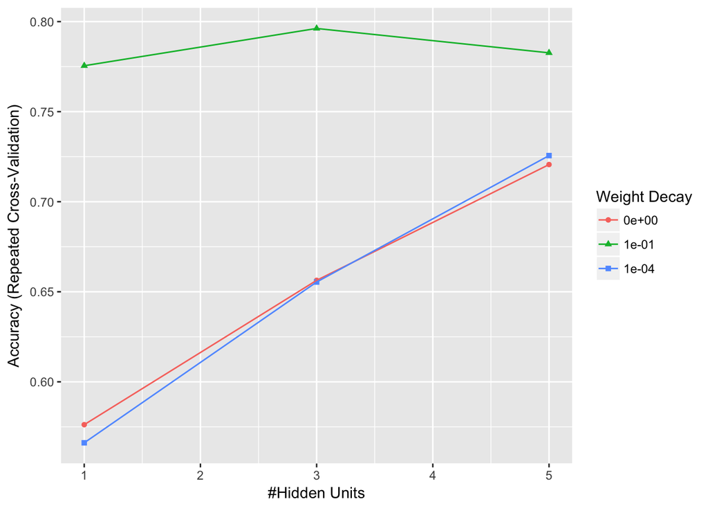

```r
ggplot(nnet.model)
```

```r
importance = varImp(nnet.model, scale=FALSE)
importance
```

```
## nnet variable importance
##
##          Overall
## cp2      15.4286
## exang1   14.2669
## cp4      12.4885
## cp3      12.3490
## oldpeak  10.5689
## restecg1 10.1935
## sexmale   9.9430
## fbs1      7.8338
## restecg2  2.7411
## age       2.0853
## trestbps  1.0302
## chol      0.8389
## thalach   0.2322
```

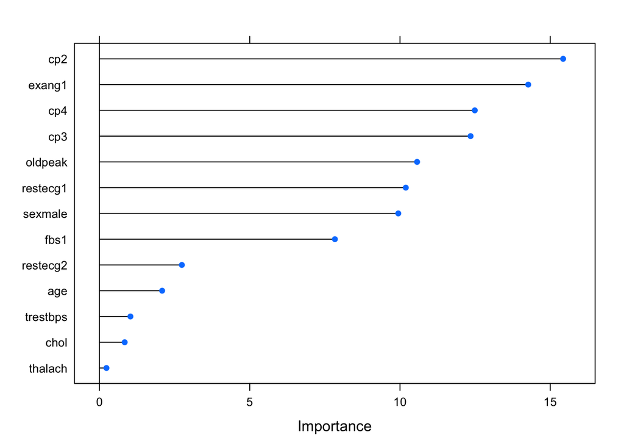

```r
plot(importance)
```